# `Project - MovieLens Data Analysis`

```
   Rating  Frequency  Percentage (%)
0       4      34174           34.17
1       3      27145           27.15
2       5      21201           21.20
3       2      11370           11.37
4       1       6110            6.11
```

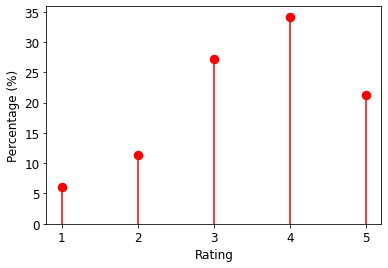

```python
#RATING
rating = pd.DataFrame(data['rating'].value_counts())
total_ratings = data['rating'].value_counts().sum()          #Find frequency of ratings and make new dataframe
rating.head(6)
rating['percent'] = rating['rating']/total_ratings*100       #Calculating percentage of ratings
rating['percent'] = round(rating['percent'], 2)
rating.head(6)
rating.reset_index(inplace=True)
rating.head(6)
rating.columns
rating.columns = ['Rating', 'Frequency', 'Percentage (%)']   #Naming table columns
print(rating.head())

## Making lollipop chart in Matplotlib to show percentage of ratings.
(markerline, stemlines, baseline) = mplt.stem(rating['Rating'],
                                             rating['Percentage (%)'])
mplt.setp(markerline, marker='.', markersize=15,
         markeredgewidth=2, color='red')
mplt.setp(stemlines, color='red')
mplt.setp(baseline, visible=False)

mplt.tick_params(labelsize=12)
mplt.xlabel('Rating', size=12)
mplt.ylabel('Percentage (%)', size=12)
mplt.xticks([1, 2, 3, 4, 5])
mplt.ylim(bottom=0)

mplt.show()
```

```
  Gender  Frequency  Percentage (%)
0      M        670           71.05
1      F        273           28.95
```

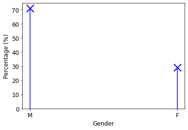

```python
#GENDER
gender = pd.DataFrame(user['gender'].value_counts())
total = user['gender'].value_counts().sum()
gender['percent'] = gender['gender']/total*100
gender['percent'] = round(gender['percent'], 2)
gender.head()

gender.reset_index(inplace=True)
gender.head(6)
gender.columns
gender.columns = ['Gender', 'Frequency', 'Percentage (%)']
print(gender.head())

(markerline, stemlines, baseline) = mplt.stem(gender['Gender'],
                                             gender['Percentage (%)'])
mplt.setp(markerline, marker='x', markersize=15,
         markeredgewidth=2, color='blue')
mplt.setp(stemlines, color='blue')
mplt.setp(baseline, visible=False)

mplt.tick_params(labelsize=12)
mplt.xlabel('Gender', size=12)
mplt.ylabel('Percentage (%)', size=12)
mplt.ylim(bottom=0)

mplt.show()
```

```
       Occupation  Frequency  Percentage (%)
0         student        196           20.78
1           other        105           11.13
2        educator         95           10.07
3   administrator         79            8.38
4        engineer         67            7.10
5      programmer         66            7.00
6       librarian         51            5.41
7          writer         45            4.77
8       executive         32            3.39
9       scientist         31            3.29
10         artist         28            2.97
11     technician         27            2.86
12      marketing         26            2.76
13  entertainment         18            1.91
14     healthcare         16            1.70
15        retired         14            1.48
16         lawyer         12            1.27
17       salesman         12            1.27
18           none          9            0.95
19      homemaker          7            0.74
20         doctor          7            0.74
```

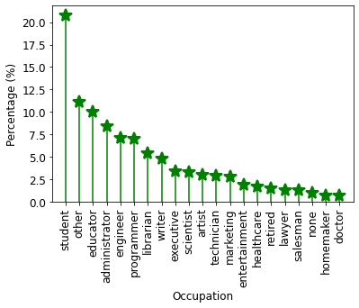

```python
##OCCUPATION

occupation = pd.DataFrame(user['occupation'].value_counts())
total_occup = user['occupation'].value_counts().sum()
occupation['percent'] = occupation['occupation']/total_occup*100
occupation['percent'] = round(occupation['percent'], 2)
occupation.head()

occupation.reset_index(inplace=True)
occupation.head(6)
occupation.columns
occupation.columns = ['Occupation', 'Frequency', 'Percentage (%)']
print(occupation)

(markerline, stemlines, baseline) = mplt.stem(occupation['Occupation'],
                                             occupation['Percentage (%)'])
mplt.setp(markerline, marker='*', markersize=15,
         markeredgewidth=2, color='green')
mplt.setp(stemlines, color='green')
mplt.setp(baseline, visible=False)

mplt.tick_params(labelsize=12)
mplt.xlabel('Occupation', size=12)
mplt.ylabel('Percentage (%)', size=12)
mplt.xticks(rotation=90)
mplt.ylim(bottom=0)

mplt.show()
```

### When I plotted the data as lollipop charts in Matplotlib, 4 is the most popular rating. Students comprised the largest group of the study and most participants were male.

### 8. Visualize how popularity of genres has changed over the years - 10 marks

Note that you need to use the **percent of number of releases in a year** as a parameter of popularity of a genre

Hint 1: You need to reach to a data frame where the release year is the index and the genre is the column names (one cell shows the number of release in a year in one genre) or vice versa. (Drop unnecessary column if there are any)

Hint 2: Find the total number of movies release in a year(use `sum(axis=1)` store that value in a new column as 'total'). Now divide the value of each genre in that year by total to get percentage number of release in a particular year. `(df.div(df['total'], axis= 0) * 100)`

Once that is achieved, you can either use univariate plots or can use the heatmap to visualise all the changes over the years in one go.

Hint 3: Use groupby on the relevant column and use sum() on the same to find out the number of releases in a year/genre.

```
                 Action  Adventure  Animation  Childrens     Comedy  \
release_year
1922           0.000000   0.000000   0.000000   0.000000   0.000000
1926           0.000000   0.000000   0.000000   0.000000   0.000000
1930           0.000000   0.000000   0.000000   0.000000   0.000000
1931           0.000000   0.000000   0.000000   0.000000   0.000000
1932           0.000000   0.000000   0.000000   0.000000   0.000000
...                 ...        ...        ...        ...        ...
1994           8.498584   3.682720   1.133144   4.249292  23.229462
1995          10.498688   5.774278   1.574803   5.511811  16.535433
1996           7.871199   4.293381   1.610018   3.756708  19.320215
1997           9.274194   4.032258   0.604839   4.435484  17.540323
1998          10.256410   2.564103   0.000000   0.854701  11.111111

                  Crime  Documentary       Drama   Fantasy  Film-Noir  \
```

[output cut: 42 more lines]

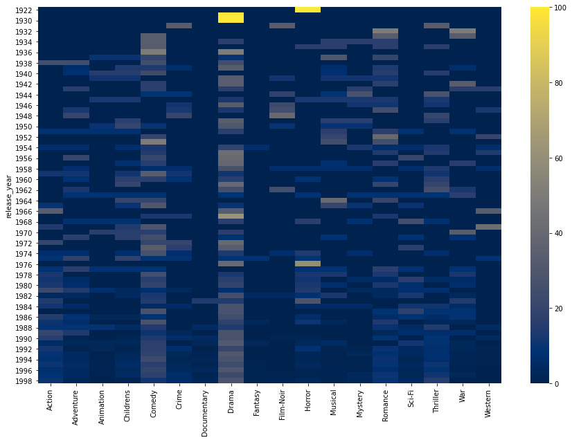

```python
item.head()
item_year_action = item.groupby(['release_year'])[['unknown', 'Action', 'Adventure', 'Animation', 'Childrens', 'Comedy', 'Crime', 'Documentary', 'Drama', 'Fantasy', 'Film-Noir', 'Horror', 'Musical', 'Mystery', 'Romance', 'Sci-Fi', 'Thriller', 'War', 'Western']].sum().reset_index()
item_year_action.tail()                                                           #Using groupby function, and sum()

item_year_action['total'] = item_year_action.sum(axis=1)                         #Sum the genre columns and place result in 'total' column
item_year_action.tail()
item_year_action2 = item_year_action.set_index('release_year')                   #Make release_year the index
item_year_action2.info
item_year_action2.dtypes
movie_release_per_year_percent = item_year_action2.iloc[:,1:19].div(item_year_action2.total, axis=0)*100      #Get percentage of each genre in each year
print(movie_release_per_year_percent)

fig, ax = mplt.subplots(figsize=(15,10))                                  #Setting dimensions of heatmap
sns.heatmap(movie_release_per_year_percent, cmap = "cividis");            #Change color of heatmap
```

### Of all the genres, drama films were released more frequently over the years compared to other genres. Comedy also is popular throughout the years. Horror films, on the other hand, were released a lot in the 1922, but failed to garner similar level of interest later on, with the exception of 1976.

### 9. Find the top 25 movies according to average ratings such that each movie has number of ratings more than 100 - 10 marks

Hints :

1. Find the count of ratings and average ratings for every movie.
2. Slice the movies which have ratings more than 100.
3. Sort values according to average rating such that movie which highest rating is on top.
4. Select top 25 movies.
5. You will have to use the .merge() function to get the movie titles.

Note: This question will need you to research about groupby and apply your findings. You can find more on groupby on https://realpython.com/pandas-groupby/.

```
                                           movie title  Rating Count  \
152                                    Close Shave, A            503
590                                  Schindler's List           1331
758                               Wrong Trousers, The            527
127                                        Casablanca           1083
736   Wallace & Gromit: The Best of Aardman Animation            298
610                         Shawshank Redemption, The           1258
555                                       Rear Window            917
726                               Usual Suspects, The           1171
654                                         Star Wars           2541
1                                        12 Angry Men            543
684                                    Third Man, The            312
142                                      Citizen Kane            850
629                  Some Folks Call It a Sling Blade            176
700                             To Kill a Mockingbird            940
```

[output cut: 38 more lines]

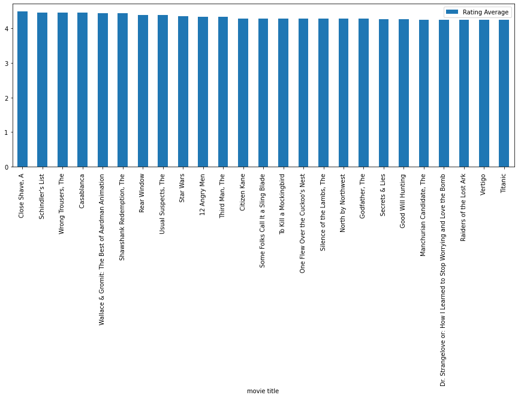

```python
data.head()
item.head()
movie_rating = pd.merge(item,data,how='left',on='movie id')   #Left merge to retain the movie list from the item dataset
movie_rating.head()
movie_rating2 = movie_rating.groupby(['movie title'])[['rating']].mean().reset_index()  #Average Ratings
movie_rating2.tail()
movie_rating.head()
movie_rating3 = movie_rating.groupby(['movie title'])[['rating']].sum().reset_index()   #Count of Ratings
movie_rating3.tail()
movie_rating_over_100 = movie_rating3[(movie_rating3['rating'] > 100)]               #Subsetting movies with more than 100 ratings
movie_rating_over_100.tail()
movie_rating_over_100_avg_rating = pd.merge(movie_rating_over_100, movie_rating2, how = 'left', on='movie title')     # Making frequency table to show frequency and average rating
movie_rating_over_100_avg_rating.head()
movie_rating_over_100_avg_rating.columns = ['movie title', 'Rating Count', 'Rating Average']   #Change the column titles.

print(movie_rating_over_100_avg_rating.sort_values(['Rating Average'],                   #Display table
                    ascending=False).head(25))
movie_rating_over_100_avg_rating.sort_values(['Rating Average'],                         #Creating bar chart of top 25 films with oveer 100 ratings
                    ascending=False).head(25).plot(x='movie title',y='Rating Average',kind='bar', figsize=(15,5))

mplt.show()
```

### 10. See gender distribution across different genres check for the validity of the below statements - 10 marks

- Men watch more drama than women
- Women watch more Sci-Fi than men
- Men watch more Romance than women

**compare the percentages**

1. Merge all the datasets
2. There is no need to conduct statistical tests around this. Just **compare the percentages** and comment on the validity of the above statements.
3. you might want ot use the .sum(), .div() function here.
4. Use number of ratings to validate the numbers. For example, if out of 4000 ratings received by women, 3000 are for drama, we will assume that 75% of the women watch drama.

```python
#Merge all datasets
movie = pd.merge(item, data, how = 'outer', on = 'movie id') #Merge item and data datasets
movie_user = pd.merge(movie, user, how = 'outer', on = 'user id') #Merge previous merged dataset with user dataset
movie_user.head()


#Verifying if men watch more drama than women.

gender_drama = movie_user.groupby(by=['gender'])['Drama'].sum().reset_index().sort_values(['Drama']).tail(10)
gender_total_drama = gender_drama['Drama'].sum()
gender_drama['Percent'] = round(gender_drama['Drama']/gender_total_drama * 100, 2)
print('Question 2 : Percentage of males and females who watch drama.')
print(gender_drama)

#Number of Rankings by Gender
rating_no_gender = movie_user.groupby(by=['gender'])['rating'].sum().reset_index().sort_values(['rating']).tail(10)
print('Number of rankings by Gender')
print(rating_no_gender)

#Checking to see the percentage of drama viewers amongst male and female raters
gender_drama['Percent_rankings'] = round(gender_drama['Drama']/rating_no_gender['rating'] * 100, 2)     #Getting the percentage of each gender who watch drama from all the ratings from that gender
print('Question 4: Percentage of drama viewers amongs male and female rating entries')
print(gender_drama)
```

```
Question 2 : Percentage of males and females who watch drama.
  gender    Drama  Percent
0      F  11008.0    27.59
1      M  28887.0    72.41
Number of rankings by Gender
  gender  rating
0      F   90901
1      M  262085
Question 4: Percentage of drama viewers amongs male and female rating entries
  gender    Drama  Percent  Percent_rankings
0      F  11008.0    27.59             12.11
1      M  28887.0    72.41             11.02
```

### Question 2: Among people who watched drama films, more men (N=28887, 72.41%) watched drama than women (N=11008, 27.59%) did.

### Question 4: However, among female raters, 12.11% watched drama. Among male raters, only 11.02% view drama films.

```python
#Verifying if women watch more sci-fi than men


gender_scifi = movie_user.groupby(by=['gender'])['Sci-Fi'].sum().reset_index().sort_values(['Sci-Fi']).tail(10)
gender_total_scifi = gender_scifi['Sci-Fi'].sum()
gender_scifi['Percent'] = round(gender_scifi['Sci-Fi']/gender_total_scifi * 100, 2)
print('Question 2 : Percentage of males and females who watch sci-fi.')
print(gender_scifi)


#Checking to see the percentage of sci-fi viewers amongst male and female raters
gender_scifi['Percent_rankings'] = round(gender_scifi['Sci-Fi']/rating_no_gender['rating'] * 100, 2)     #Getting the percentage of each gender who watch sci-fi from all the ratings from that gender
print('Question 4: Percentage of sci-fi viewers amongs male and female rating entries')
print(gender_scifi)
```

```
Question 2 : Percentage of males and females who watch sci-fi.
  gender   Sci-Fi  Percent
0      F   2629.0    20.65
1      M  10101.0    79.35
Question 4: Percentage of sci-fi viewers amongs male and female rating entries
  gender   Sci-Fi  Percent  Percent_rankings
0      F   2629.0    20.65              2.89
1      M  10101.0    79.35              3.85
```

### Question 2: According to these merged datasets, more men (N=10101, 79.35%) watched sci-fi compared to women (N= 2629, 20.65%).

```python
#Verifying if men watch more romance than women

gender_romance = movie_user.groupby(by=['gender'])['Romance'].sum().reset_index().sort_values(['Romance']).tail(10)
gender_total_romance = gender_romance['Romance'].sum()
gender_romance['Percent'] = round(gender_romance['Romance']/gender_total_romance * 100, 2)
print('Question 2 : Percentage of males and females who watch romance.')
print(gender_romance)


#Checking to see the percentage of romance viewers amongst male and female raters
gender_romance['Percent_rankings'] = round(gender_romance['Romance']/rating_no_gender['rating'] * 100, 2)     #Getting the percentage of each gender who watch romance from all the ratings from that gender
print('Question 4: Percentage of romance viewers amongs male and female rating entries')
print(gender_romance)
```

```
Question 2 : Percentage of males and females who watch romance.
  gender  Romance  Percent
0      F   5858.0     30.1
1      M  13603.0     69.9
Question 4: Percentage of romance viewers amongs male and female rating entries
  gender  Romance  Percent  Percent_rankings
0      F   5858.0     30.1              6.44
1      M  13603.0     69.9              5.19
```

### Question 2: Amongst people who watched romance films, there were more males (N= 13603, 69.9%) compared to females (N= 5858, 30.1%)

### Question 4: Amongst all male raters who participated in the study, 5.19% watched romance movies. Amongst all females who participated in the study, 6.44% watched romance films.